# The RMS TITANIC Survivors

# Exploratory analysis

By making exploratory plots, we can quickly obtain insights from this dataset.

For example, the overall survival for 2nd Class passenger tells us that 1/3 of the passengers survived, but if we differentiate by sex we will see that the % of females that survived was roughly inversely proportional to the male survivors. Thus, we can confirm that the “women first” call was indeed observed for the 2nd Class passengers.

```
## [[1]]
## [1] 2nd 2nd 2nd 2nd 2nd 2nd 2nd 2nd
## Levels: 1st 2nd 3rd Crew
```

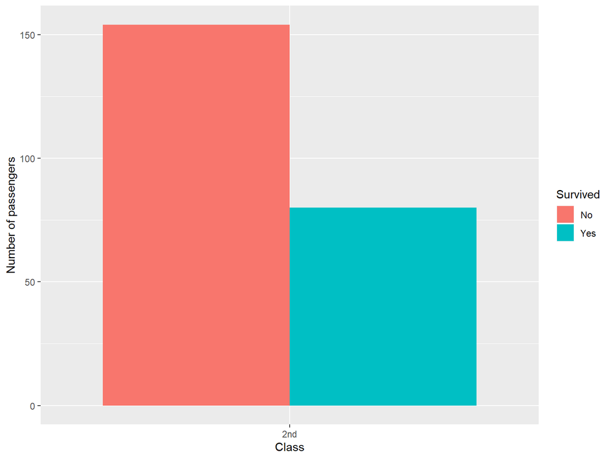

**2nd Class FEMALE passengers**

```
## [[1]]
## [1] 2nd 2nd 2nd 2nd 2nd 2nd 2nd 2nd
## Levels: 1st 2nd 3rd Crew
```

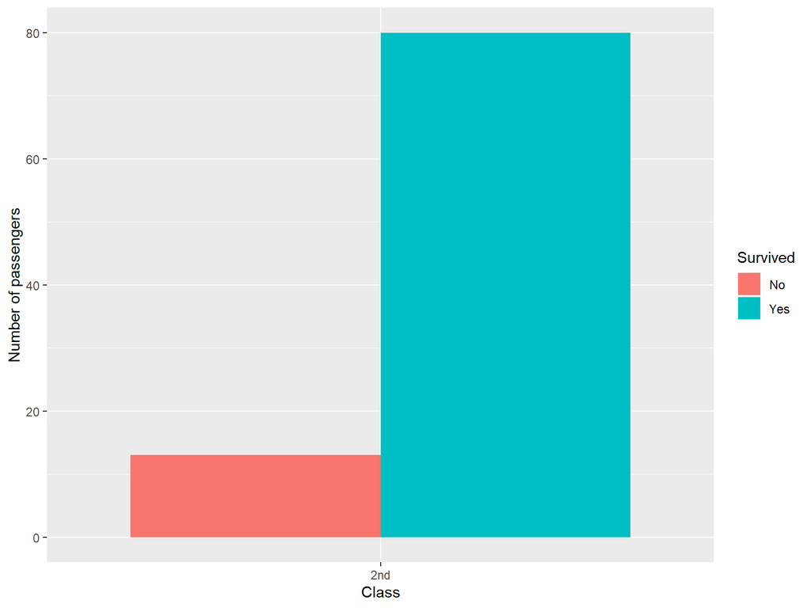

**2nd Class MALE passengers**

```
## [[1]]
## [1] 2nd 2nd 2nd 2nd 2nd 2nd 2nd 2nd
## Levels: 1st 2nd 3rd Crew
```

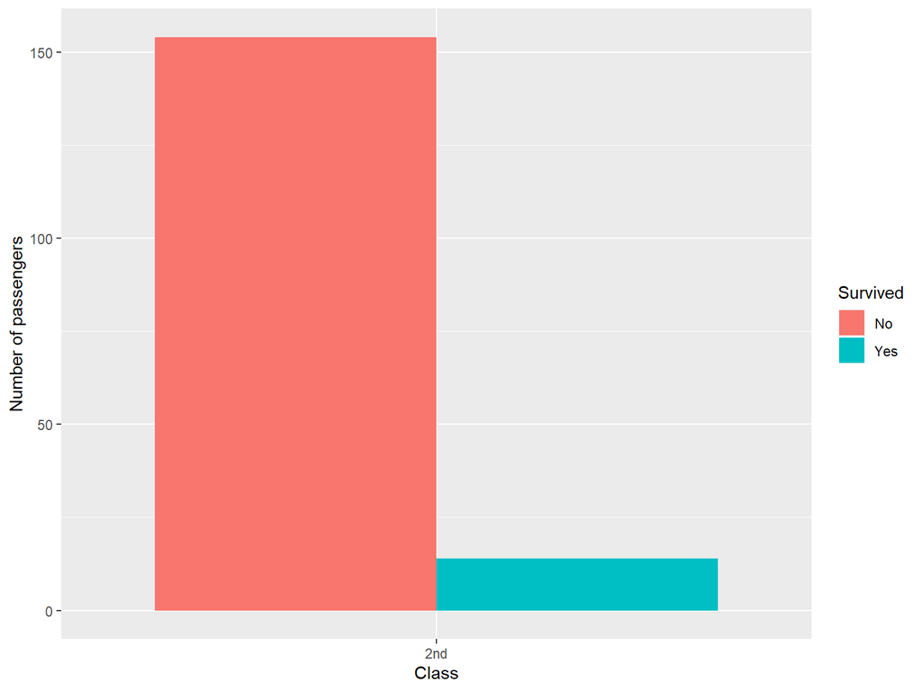